# R Notebook

# Assignment 06

Baran Gulmez

# Load Libraries

```r
library(mlr)
library(tidyverse)
library(DataExplorer)
library(factoextra)
library(dendextend)
library(reshape2)
library(ggforce)
library(cluster)
library(corrplot)
library(ggplot2)
library(ggpubr) # this might be conflicting (select function)
library(MASS) # this might be conflicting (select function)
              # MASS library is used isoMDS()
library(conflicted)
library(factoextra) # for fviz
library(clusterCrit) # cluster validation (intCriteria function)
library(clValid) # (clValid function)
```

# Read Dataset

The sample Dataset summarizes the usage behavior of about 9000 active credit card holders during the last 6 months.

CUSTID : Identification of Credit Card holder (Categorical)  
BALANCE : Balance amount left in their account to make purchases  
BALANCEFREQUENCY : How frequently the Balance is updated, score between 0 and 1 (1 = frequently updated, 0 = not frequently updated)  
PURCHASES : Amount of purchases made from account  
ONEOFFPURCHASES : Maximum purchase amount done in one-go  
INSTALLMENTSPURCHASES : Amount of purchase done in installment  
CASHADVANCE : Cash in advance given by the user  
PURCHASESFREQUENCY : How frequently the Purchases are being made, score between 0 and 1 (1 = frequently purchased, 0 = not frequently purchased)  
ONEOFFPURCHASESFREQUENCY : How frequently Purchases are happening in one-go (1 = frequently purchased, 0 = not frequently purchased)  
PURCHASESINSTALLMENTSFREQUENCY : How frequently purchases in installments are being done (1 = frequently done, 0 = not frequently done)  
CASHADVANCEFREQUENCY : How frequently the cash in advance being paid  
CASHADVANCETRX : Number of Transactions made with “Cash in Advanced”  
PURCHASESTRX : Numbe of purchase transactions made  
CREDITLIMIT : Limit of Credit Card for user  
PAYMENTS : Amount of Payment done by user  
MINIMUM_PAYMENTS : Minimum amount of payments made by user  
PRCFULLPAYMENT : Percent of full payment paid by user  
TENURE : Tenure of credit card service for user

```r
dat = read.csv("input/CC GENERAL.csv",
               stringsAsFactors = F,
               na.strings = c(" "))
```

# Basic Analysis

```r
glimpse(dat)
```

```
Rows: 8,950
Columns: 18
$ CUST_ID                          <chr> "C10001", "C10002", "C10003", "C10004", "C10005", "C10006", "C10007", "C10008", "C10009", "C10010~
$ BALANCE                          <dbl> 40.90075, 3202.46742, 2495.14886, 1666.67054, 817.71434, 1809.82875, 627.26081, 1823.65274, 1014.~
$ BALANCE_FREQUENCY                <dbl> 0.818182, 0.909091, 1.000000, 0.636364, 1.000000, 1.000000, 1.000000, 1.000000, 1.000000, 0.54545~
$ PURCHASES                        <dbl> 95.40, 0.00, 773.17, 1499.00, 16.00, 1333.28, 7091.01, 436.20, 861.49, 1281.60, 920.12, 1492.18, ~
$ ONEOFF_PURCHASES                 <dbl> 0.00, 0.00, 773.17, 1499.00, 16.00, 0.00, 6402.63, 0.00, 661.49, 1281.60, 0.00, 1492.18, 2500.23,~
$ INSTALLMENTS_PURCHASES           <dbl> 95.40, 0.00, 0.00, 0.00, 0.00, 1333.28, 688.38, 436.20, 200.00, 0.00, 920.12, 0.00, 717.76, 1717.~
$ CASH_ADVANCE                     <dbl> 0.00000, 6442.94548, 0.00000, 205.78802, 0.00000, 0.00000, 0.00000, 0.00000, 0.00000, 0.00000, 0.~
$ PURCHASES_FREQUENCY              <dbl> 0.166667, 0.000000, 1.000000, 0.083333, 0.083333, 0.666667, 1.000000, 1.000000, 0.333333, 0.16666~
$ ONEOFF_PURCHASES_FREQUENCY       <dbl> 0.000000, 0.000000, 1.000000, 0.083333, 0.083333, 0.000000, 1.000000, 0.000000, 0.083333, 0.16666~
$ PURCHASES_INSTALLMENTS_FREQUENCY <dbl> 0.083333, 0.000000, 0.000000, 0.000000, 0.000000, 0.583333, 1.000000, 1.000000, 0.250000, 0.00000~
$ CASH_ADVANCE_FREQUENCY           <dbl> 0.000000, 0.250000, 0.000000, 0.083333, 0.000000, 0.000000, 0.000000, 0.000000, 0.000000, 0.00000~
$ CASH_ADVANCE_TRX                 <int> 0, 4, 0, 1, 0, 0, 0, 0, 0, 0, 0, 0, 0, 0, 1, 4, 3, 0, 0, 0, 0, 6, 0, 13, 4, 0, 5, 0, 16, 0, 10, 2~
$ PURCHASES_TRX                    <int> 2, 0, 12, 1, 1, 8, 64, 12, 5, 3, 12, 6, 26, 26, 0, 11, 0, 8, 9, 12, 8, 92, 17, 13, 0, 12, 2, 12, ~
$ CREDIT_LIMIT                     <dbl> 1000, 7000, 7500, 7500, 1200, 1800, 13500, 2300, 7000, 11000, 1200, 2000, 3000, 7500, 3000, 8000,~
$ PAYMENTS                         <dbl> 201.8021, 4103.0326, 622.0667, 0.0000, 678.3348, 1400.0578, 6354.3143, 679.0651, 688.2786, 1164.7~
$ MINIMUM_PAYMENTS                 <dbl> 139.50979, 1072.34022, 627.28479, NA, 244.79124, 2407.24604, 198.06589, 532.03399, 311.96341, 100~
$ PRC_FULL_PAYMENT                 <dbl> 0.000000, 0.222222, 0.000000, 0.000000, 0.000000, 0.000000, 1.000000, 0.000000, 0.000000, 0.00000~
$ TENURE                           <int> 12, 12, 12, 12, 12, 12, 12, 12, 12, 12, 12, 12, 12, 12, 12, 12, 8, 12, 12, 12, 12, 12, 12, 12, 11~
```

## Missing Data

An insignificant portion of the data is missing.

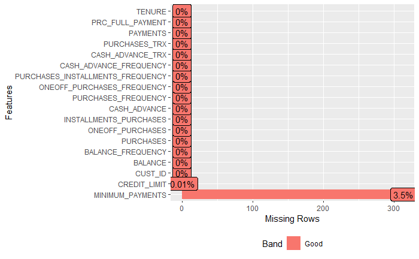

```r
plot_missing(dat)
```

## Summaryy

```r
summary(dat)
```

```
   CUST_ID             BALANCE        BALANCE_FREQUENCY   PURCHASES        ONEOFF_PURCHASES  INSTALLMENTS_PURCHASES  CASH_ADVANCE
 Length:8950        Min.   :    0.0   Min.   :0.0000    Min.   :    0.00   Min.   :    0.0   Min.   :    0.0        Min.   :    0.0
 Class :character   1st Qu.:  128.3   1st Qu.:0.8889    1st Qu.:   39.63   1st Qu.:    0.0   1st Qu.:    0.0        1st Qu.:    0.0
 Mode  :character   Median :  873.4   Median :1.0000    Median :  361.28   Median :   38.0   Median :   89.0        Median :    0.0
                    Mean   : 1564.5   Mean   :0.8773    Mean   : 1003.20   Mean   :  592.4   Mean   :  411.1        Mean   :  978.9
                    3rd Qu.: 2054.1   3rd Qu.:1.0000    3rd Qu.: 1110.13   3rd Qu.:  577.4   3rd Qu.:  468.6        3rd Qu.: 1113.8
                    Max.   :19043.1   Max.   :1.0000    Max.   :49039.57   Max.   :40761.2   Max.   :22500.0        Max.   :47137.2

 PURCHASES_FREQUENCY ONEOFF_PURCHASES_FREQUENCY PURCHASES_INSTALLMENTS_FREQUENCY CASH_ADVANCE_FREQUENCY CASH_ADVANCE_TRX  PURCHASES_TRX
 Min.   :0.00000     Min.   :0.00000            Min.   :0.0000                   Min.   :0.0000         Min.   :  0.000   Min.   :  0.00
 1st Qu.:0.08333     1st Qu.:0.00000            1st Qu.:0.0000                   1st Qu.:0.0000         1st Qu.:  0.000   1st Qu.:  1.00
 Median :0.50000     Median :0.08333            Median :0.1667                   Median :0.0000         Median :  0.000   Median :  7.00
 Mean   :0.49035     Mean   :0.20246            Mean   :0.3644                   Mean   :0.1351         Mean   :  3.249   Mean   : 14.71
 3rd Qu.:0.91667     3rd Qu.:0.30000            3rd Qu.:0.7500                   3rd Qu.:0.2222         3rd Qu.:  4.000   3rd Qu.: 17.00
 Max.   :1.00000     Max.   :1.00000            Max.   :1.0000                   Max.   :1.5000         Max.   :123.000   Max.   :358.00

  CREDIT_LIMIT      PAYMENTS       MINIMUM_PAYMENTS   PRC_FULL_PAYMENT     TENURE
 Min.   :   50   Min.   :    0.0   Min.   :    0.02   Min.   :0.0000   Min.   : 6.00
 1st Qu.: 1600   1st Qu.:  383.3   1st Qu.:  169.12   1st Qu.:0.0000   1st Qu.:12.00
 Median : 3000   Median :  856.9   Median :  312.34   Median :0.0000   Median :12.00
 Mean   : 4494   Mean   : 1733.1   Mean   :  864.21   Mean   :0.1537   Mean   :11.52
 3rd Qu.: 6500   3rd Qu.: 1901.1   3rd Qu.:  825.49   3rd Qu.:0.1429   3rd Qu.:12.00
 Max.   :30000   Max.   :50721.5   Max.   :76406.21   Max.   :1.0000   Max.   :12.00
 NA's   :1                         NA's   :313
```

## Histograms

Here it is seen that almost all features are skewed.

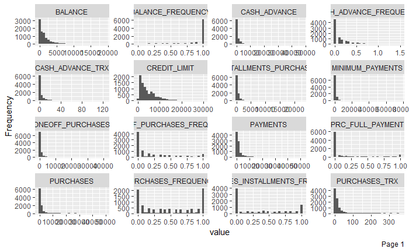

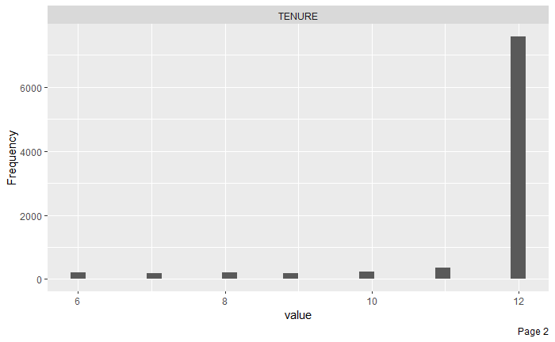

```r
plot_histogram(dat)
```

# Data Reorganization

Missing data deleted and some useless CUST_ID deleted.

```r
dat_reorg = dat %>%
  dplyr::select(-CUST_ID) %>% # calling select from dplyr to prevent conflict
  drop_na()
#
# shuffle data
if(FALSE){
set.seed(357) # fix seed
dat_reorg_backup <- dat_reorg[sample(nrow(dat_reorg)), ] # generate random index using sample and
dat_reorg = dat_reorg_backup[1:100,1:ncol(dat_reorg_backup)] # choose first 100
}
```

# Correlation

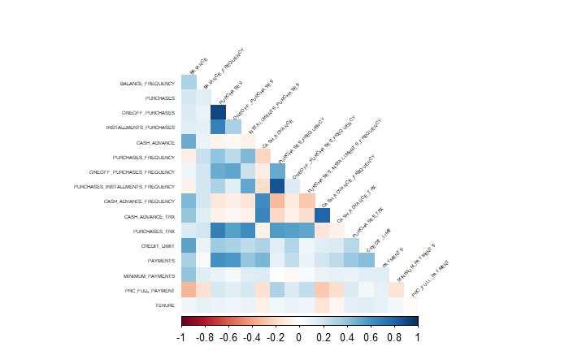

```r
corrplot(cor(dat_reorg), diag = FALSE, type = "lower", tl.srt = 45, tl.col = "black", method = 'color', tl.cex = 0.4)
```

# PCA

prcomp() expects the samples to be rows to be columns

```r
dat_reorg_scaled = scale(dat_reorg)
pca <-prcomp(dat_reorg_scaled)
```

## PCA Analysis

Scree plot shows how much the principal components are responsible the PCA component is responsible of the variation of the data.

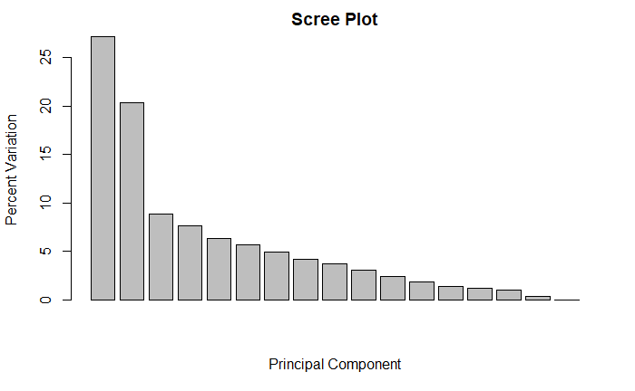

```r
pca.var <- pca$sdev^2
pca.var.per <- round(pca.var/sum(pca.var)*100, 1)
barplot(pca.var.per, main="Scree Plot", xlab="Principal Component", ylab="Percent Variation")
```

format the data

```r
pca.data <- data.frame(Sample=rownames(dat_reorg), X=pca$x[,1], Y=pca$x[,2])
pca.data
```

| Sample | X | Y |
| --- | --- | --- |
| 1 | -1.696297065 | -1.122518989 |
| 2 | -1.215610445 | 2.435496753 |
| 3 | 0.935799104 | -0.385179263 |
| 4 | -1.614544792 | -0.724544205 |
| 5 | 0.223687663 | -0.783564452 |
| 6 | 6.265235048 | -0.609413897 |
| 7 | 0.261651730 | -1.295560288 |
| 8 | -0.465311641 | -0.477670250 |
| 9 | -0.599646437 | -0.408567662 |
| 10 | 0.522740791 | -1.312087280 |

[output cut: 990 more lines]

plot the data but with indexes

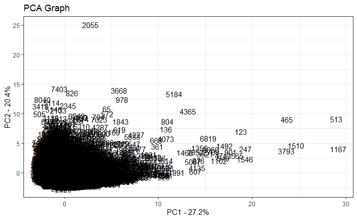

```r
ggplot(data=pca.data, aes(x=X, y=Y, label=Sample)) +
  geom_text() +
  xlab(paste("PC1 - ", pca.var.per[1], "%", sep="")) +
  ylab(paste("PC2 - ", pca.var.per[2], "%", sep="")) +
  theme_bw() +
  ggtitle("PCA Graph")
```

```r
# just another way to draw first two principal components
# plot(pca$x[,1], pca$x[,2], main="First two PCs", xlab = paste("PC1 - ", pca.var.per[1], "%", sep="") , ylab=paste("PC2 - ", pca.var.per[2], "%", sep=""))
```

Negative loading scores push left as positive ones push right.

```r
loading_scores <- pca$rotation[,1]
loading_scores_abs <- abs(loading_scores)
loading_scores
```

```
                         BALANCE                BALANCE_FREQUENCY                        PURCHASES                 ONEOFF_PURCHASES
                      0.09198590                       0.10981218                       0.41215123                       0.34677536
          INSTALLMENTS_PURCHASES                     CASH_ADVANCE              PURCHASES_FREQUENCY       ONEOFF_PURCHASES_FREQUENCY
                      0.33705564                      -0.03058765                       0.32366488                       0.29476135
PURCHASES_INSTALLMENTS_FREQUENCY           CASH_ADVANCE_FREQUENCY                 CASH_ADVANCE_TRX                    PURCHASES_TRX
                      0.27722626                      -0.09914541                      -0.05696036                       0.39106653
                    CREDIT_LIMIT                         PAYMENTS                 MINIMUM_PAYMENTS                 PRC_FULL_PAYMENT
                      0.21005184                       0.26372547                       0.05932632                       0.13056503
                          TENURE
                      0.07791867
```

## Multi-Dimensional Scaling (MDS)

Euclidean and manhattan distances are most widely used distance metrics. Therefore they are chosen as distance metrics. These two distances also usually work the best to my experience.

```r
distEuc.matrix <- stats::dist(dat_reorg_scaled, method="euclidean")
distMnh.matrix <- stats::dist(dat_reorg_scaled, method="manhattan")
```

### Classical Multi-Dimensional Scaling

#### Euclidean Distance

```r
mdsCmdEuc.stuff <- cmdscale(distEuc.matrix, eig=TRUE, x.ret=TRUE)
mdsCmdEuc.var.per <- round(mdsCmdEuc.stuff$eig/sum(mdsCmdEuc.stuff$eig)*100, 1)
# graph
mdsCmdEuc.values <- mdsCmdEuc.stuff$points
mdsCmdEuc.data <- base::data.frame(Sample=rownames(dat_reorg), X=mdsCmdEuc.values[,1], Y=mdsCmdEuc.values[,2])
mdsCmdEuc.data
```

| Sample | X | Y |
| --- | --- | --- |
| 1 | 1.696297065 | 1.122518989 |
| 2 | 1.215610445 | -2.435496753 |
| 3 | -0.935799104 | 0.385179263 |
| 4 | 1.614544792 | 0.724544205 |
| 5 | -0.223687663 | 0.783564452 |
| 6 | -6.265235048 | 0.609413897 |
| 7 | -0.261651730 | 1.295560288 |
| 8 | 0.465311641 | 0.477670250 |
| 9 | 0.599646437 | 0.408567662 |
| 10 | -0.522740791 | 1.312087280 |

[output cut: 990 more lines]

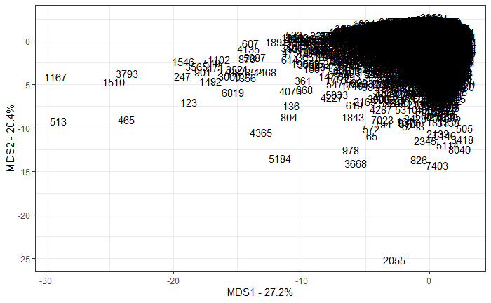

```r
ggplot(data=mdsCmdEuc.data, aes(x=X, y=Y, label=Sample)) +
  geom_text() +
  theme_bw() +
  xlab(paste("MDS1 - ", mdsCmdEuc.var.per[1], "%", sep="")) +
  ylab(paste("MDS2 - ", mdsCmdEuc.var.per[2], "%", sep=""))
```

#### Manhattan Distance

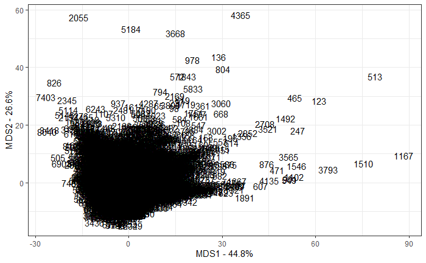

```r
mdsCmdMnh.stuff <- cmdscale(distMnh.matrix, eig=TRUE, x.ret=TRUE)
mdsCmdMnh.var.per <- round(mdsCmdMnh.stuff$eig/sum(mdsCmdMnh.stuff$eig)*100, 1)
# graph
mdsCmdMnh.values <- mdsCmdMnh.stuff$points
mdsCmdMnh.data <- data.frame(Sample=rownames(dat_reorg),
  X=mdsCmdMnh.values[,1],
  Y=mdsCmdMnh.values[,2])
ggplot(data=mdsCmdMnh.data, aes(x=X, y=Y, label=Sample)) +
  geom_text() +
  theme_bw() +
  xlab(paste("MDS1 - ", mdsCmdMnh.var.per[1], "%", sep="")) +
  ylab(paste("MDS2 - ", mdsCmdMnh.var.per[2], "%", sep=""))
```

### Metric Multi-Dimesional Scaling

#### Euclidean Distance

```r
mdsSamEuc.stuff <- sammon(distEuc.matrix)
```

```
Initial stress        : 0.18811
stress after   0 iters: 0.18811
```

```r
mdsSamEuc.var.per <- round(mdsSamEuc.stuff$eig/sum(mdsSamEuc.stuff$eig)*100, 1)
# graph
mdsSamEuc.values <- mdsSamEuc.stuff$points
mdsSamEuc.data <- base::data.frame(Sample=rownames(dat_reorg), X=mdsSamEuc.values[,1], Y=mdsSamEuc.values[,2])
mdsSamEuc.data
```

| Sample | X | Y |
| --- | --- | --- |
| 1 | 1.696297065 | 1.122518989 |
| 2 | 1.215610445 | -2.435496753 |
| 3 | -0.935799104 | 0.385179263 |
| 4 | 1.614544792 | 0.724544205 |
| 5 | -0.223687663 | 0.783564452 |
| 6 | -6.265235048 | 0.609413897 |
| 7 | -0.261651730 | 1.295560288 |
| 8 | 0.465311641 | 0.477670250 |
| 9 | 0.599646437 | 0.408567662 |
| 10 | -0.522740791 | 1.312087280 |

[output cut: 990 more lines]

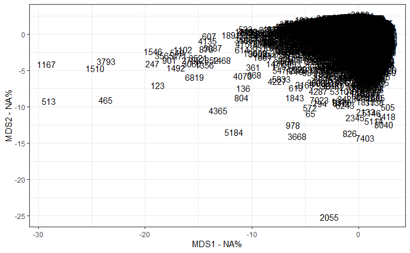

```r
ggplot(data=mdsSamEuc.data, aes(x=X, y=Y, label=Sample)) +
  geom_text() +
  theme_bw() +
  xlab(paste("MDS1 - ", mdsSamEuc.var.per[1], "%", sep="")) +
  ylab(paste("MDS2 - ", mdsSamEuc.var.per[2], "%", sep=""))
```

#### Manhattan Distance

```r
mdsSamMnh.stuff <- sammon(distMnh.matrix)
```

```
Initial stress        : 0.08243
stress after   0 iters: 0.08243
```

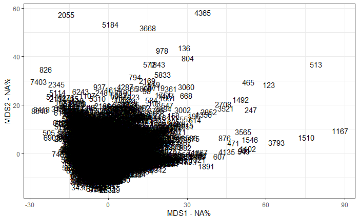

```r
mdsSamMnh.var.per <- round(mdsSamMnh.stuff$eig/sum(mdsSamMnh.stuff$eig)*100, 1)
# graph
mdsSamMnh.values <- mdsSamMnh.stuff$points
mdsSamMnh.data <- data.frame(Sample=rownames(dat_reorg),
  X=mdsSamMnh.values[,1],
  Y=mdsSamMnh.values[,2])
ggplot(data=mdsSamMnh.data, aes(x=X, y=Y, label=Sample)) +
  geom_text() +
  theme_bw() +
  xlab(paste("MDS1 - ", mdsSamMnh.var.per[1], "%", sep="")) +
  ylab(paste("MDS2 - ", mdsSamMnh.var.per[2], "%", sep=""))
```

### Non-Metric Multi-Dimensional Scaling

#### Euclidean Distance

```r
mdsIsoEuc.stuff <- isoMDS(distEuc.matrix)
# graph
mdsIsoEuc.values <- mdsIsoEuc.stuff$points
mdsIsoEuc.data <- data.frame(Sample=rownames(dat_reorg),
  X=mdsIsoEuc.values[,1],
  Y=mdsIsoEuc.values[,2])
mdsIsoEuc.data
```

| Sample | X | Y |
| --- | --- | --- |
| 1 | 1.280355162 | 0.706059168 |
| 2 | 1.053834590 | -1.813733180 |
| 3 | -1.370248828 | -0.140027266 |
| 4 | 1.258167859 | 0.432953701 |
| 5 | -0.067202264 | 0.521058485 |
| 6 | -6.106103234 | 0.760970045 |
| 7 | -0.261048357 | 1.090521517 |
| 8 | 0.451507023 | 0.240673661 |
| 9 | 0.841373045 | 0.257397005 |
| 10 | -0.431128703 | 1.150794713 |

[output cut: 990 more lines]

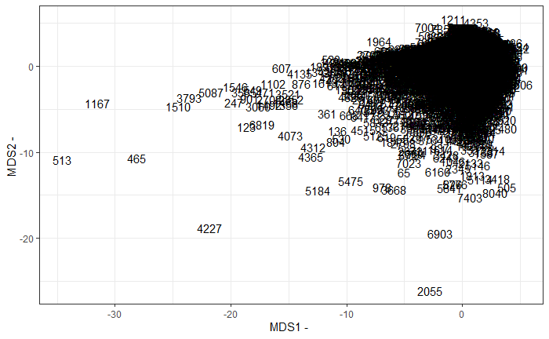

```r
ggplot(data=mdsIsoEuc.data, aes(x=X, y=Y, label=Sample)) +
  geom_text() +
  theme_bw() +
  xlab(paste("MDS1 - ")) +
  ylab(paste("MDS2 - "))
```

#### Manhattan Distance

```r
mdsIsoMnh.stuff <- isoMDS(distMnh.matrix)
# graph
mdsIsoMnh.values <- mdsIsoMnh.stuff$points
mdsIsoMnh.data <- data.frame(Sample=rownames(dat_reorg),
  X=mdsIsoMnh.values[,1],
  Y=mdsIsoMnh.values[,2])
mdsIsoMnh.data
```

| Sample | X | Y |
| --- | --- | --- |
| 1 | -4.12217468 | -4.636481458 |
| 2 | -7.06373977 | 5.807594099 |
| 3 | 3.85313180 | 1.463960055 |
| 4 | -3.71610128 | -2.772121054 |
| 5 | 2.29220920 | -0.495867094 |
| 6 | 22.81053019 | -1.216820052 |
| 7 | 2.96938601 | -1.460609252 |
| 8 | -0.12917346 | -0.424079563 |
| 9 | -1.86588575 | -2.271565354 |
| 10 | 3.80709155 | -1.360532928 |

[output cut: 990 more lines]

[figure not shown]

```r
ggplot(data=mdsIsoMnh.data, aes(x=X, y=Y, label=Sample)) +
  geom_text() +
  theme_bw() +
  xlab(paste("MDS1 - ")) +
  ylab(paste("MDS2 - "))
```

# Clustering

The reason for me to seperate the data into 3 cluster is totally intuitively. I just assumed that people would be from low, mid and high income. But inspecting hierarchical clustering, there could be 4-6 clusters ideally.

## Hierarchical

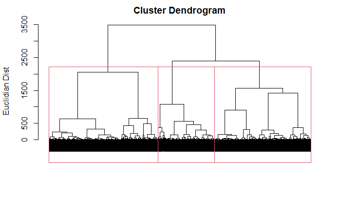

```r
clustHrc = hclust(distEuc.matrix , method = "ward.D")
plot(clustHrc, labels = FALSE, sub = "", xlab = "", ylab = "Euclidian Dist")
rect.hclust(clustHrc, k = 3)
```

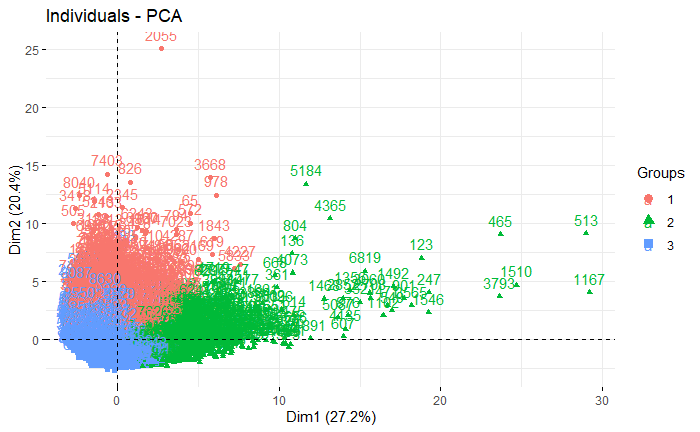

```r
clustHrcClusts = cutree(clustHrc, k = 3)
fviz_pca_ind(pca, habillage = clustHrcClusts)
```

## K-Means

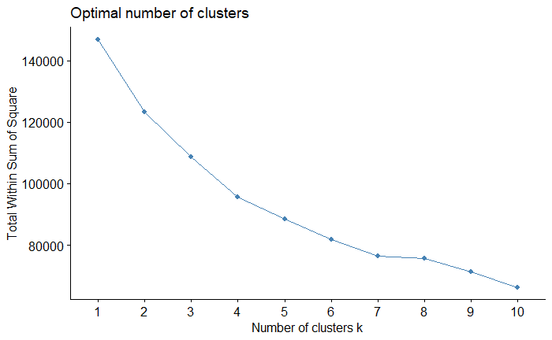

```r
# draw optimal number of cluster
fviz_nbclust(dat_reorg_scaled, kmeans, method = "wss", k.max = 10)
```

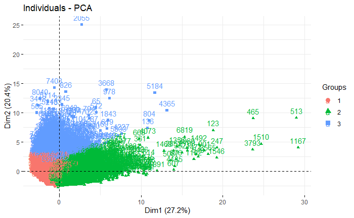

```r
clustKm = kmeans(dat_reorg_scaled, centers = 3)
fviz_pca_ind(pca, habillage = clustKm$cluster)
```

### Analyze Groups

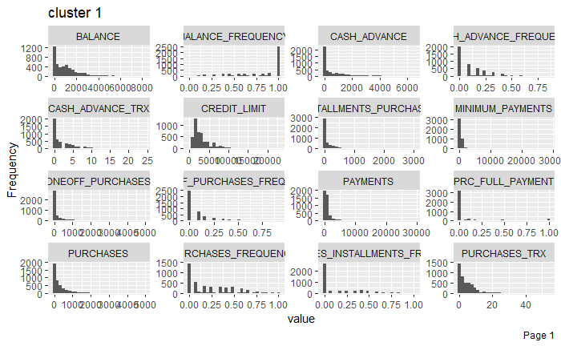

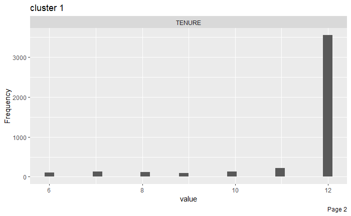

```r
clustKm1.index = which(clustKm$cluster==1)
clustKm2.index = which(clustKm$cluster==2)
clustKm3.index = which(clustKm$cluster==3)
clustKm1.dat = dat_reorg[clustKm1.index,1:ncol(dat_reorg)]
clustKm2.dat = dat_reorg[clustKm2.index,1:ncol(dat_reorg)]
clustKm3.dat = dat_reorg[clustKm3.index,1:ncol(dat_reorg)]
plot_histogram(clustKm1.dat, title="cluster 1")
```

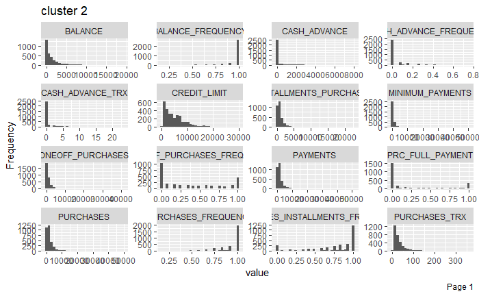

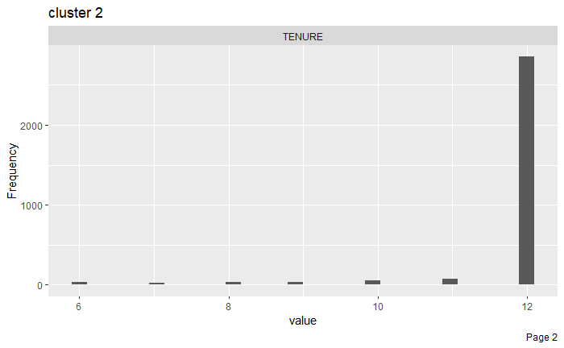

```r
plot_histogram(clustKm2.dat, title="cluster 2")
```

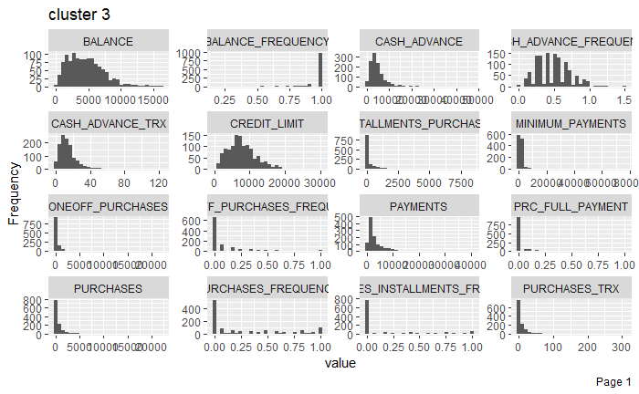

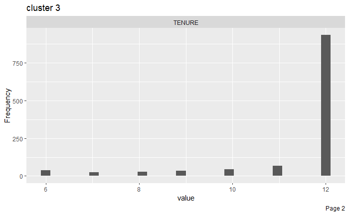

```r
plot_histogram(clustKm3.dat, title="cluster 3")
```

Even though we do these validation measures after clustering, in practice they can be applied before clustering in order to understand which configuration should be used.

```r
# https://rdrr.io/cran/clusterCrit/man/intCriteria.html
intCriteria(dat_reorg_scaled, clustKm$cluster, c("Dunn", "dav", "silhouette") )
```

```
$dunn
[1] 0.002012817

$davies_bouldin
[1] 1.663439

$silhouette
[1] 0.1524162
```

## Internal Validation

```r
# https://www.rdocumentation.org/packages/clValid/versions/0.7/topics/clValid
# https://cran.r-project.org/web/packages/clValid/vignettes/clValid.pdf
# https://rdrr.io/cran/clValid/man/clValid-class.html
valid.intern <- clValid(dat_reorg , 2:6, clMethods=c("hierarchical","kmeans"), validation="internal")
```

```
The number of items to be clustered is larger than 'maxitems'
The memory and time required may be excessive, do you wish to continue?
(y to continue, any other character to exit)
```

```r
y
summary(valid.intern)
```

```
Clustering Methods:
 hierarchical kmeans

Cluster sizes:
 2 3 4 5 6

Validation Measures:
                                  2        3        4        5        6

hierarchical Connectivity    3.2956   6.2246  14.4980  19.7726  31.1563
             Dunn            0.1943   0.1943   0.1020   0.1020   0.1020
             Silhouette      0.9081   0.8842   0.8526   0.8433   0.7935
kmeans       Connectivity  555.7802 546.5504 650.4917 855.3817 965.4060
             Dunn            0.0019   0.0025   0.0021   0.0048   0.0023
             Silhouette      0.5113   0.5095   0.4628   0.3930   0.3743

Optimal Scores:
```

|  | Score | Method | Clusters |
| --- | --- | --- | --- |
| Connectivity | 3.2956 | hierarchical | 2 |
| Dunn | 0.1943 | hierarchical | 2 |
| Silhouette | 0.9081 | hierarchical | 2 |

```r
op <- par(no.readonly=TRUE)
par(mfrow=c(2,2),mar=c(4,4,3,1))
plot(valid.intern, legend=FALSE)
plot(nClusters(valid.intern), measures(valid.intern,"Dunn")[,,1],type="n",axes=F,xlab="",ylab="")
```

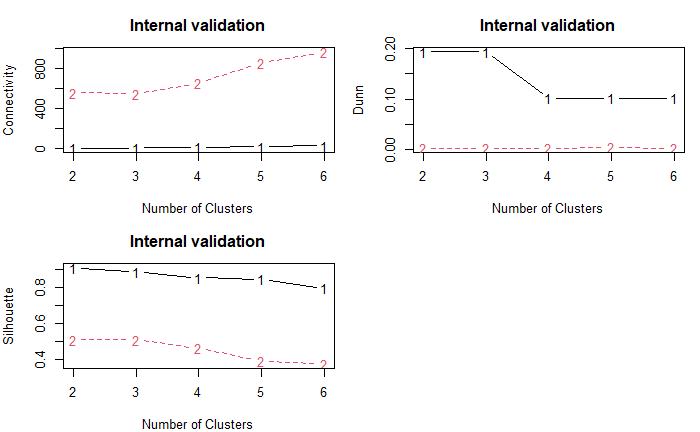

```r
legend("center", clusterMethods(valid.intern), col=1:9, lty=1:9, pch=paste(1:9))
par(op)
```

Above results show that optimal scores are achieved by hierarchical clustering with k=2.

## Stability Validation

Stabilty validation validates reproducibility of clustering solution another sample.The included measures are the average proportion of non-overlap (APN), the average distance (AD), the average distance between means (ADM), and the figure of merit (FOM) (Datta and Datta, 2003; Yeung et al., 2001). . In all cases the average is taken over all the deleted columns, and all measures should be minimized.

```r
valid.stab <- clValid(dat_reorg , 2:6, clMethods=c("hierarchical","kmeans"), validation="stability")
```

```
The number of items to be clustered is larger than 'maxitems'
The memory and time required may be excessive, do you wish to continue?
(y to continue, any other character to exit)
```

```r
y
summary(valid.stab)
```

```
Clustering Methods:
 hierarchical kmeans

Cluster sizes:
 2 3 4 5 6

Validation Measures:
                          2         3         4         5         6

hierarchical APN     0.0001    0.0009    0.0005    0.0013    0.0020
             AD   7005.3751 6992.6928 6832.9555 6825.3289 6801.3493
             ADM     7.4382   41.5973   31.1390   55.5458   77.1517
             FOM  1056.3065 1043.0755  990.3924  990.0132  988.3864
kmeans       APN     0.0221    0.0298    0.0344    0.0538    0.0670
             AD   5738.2163 5618.7797 5282.4759 4990.7224 4839.7741
             ADM   257.3348  362.1208  361.9208  561.9007  663.1631
             FOM   985.5752  991.3582  941.7552  936.3058  912.5554

Optimal Scores:
```

|  | Score | Method | Clusters |
| --- | --- | --- | --- |
| APN | 0.0001 | hierarchical | 2 |
| AD | 4839.7741 | kmeans | 6 |
| ADM | 7.4382 | hierarchical | 2 |
| FOM | 912.5554 | kmeans | 6 |

```r
par(mfrow=c(2,2),mar=c(4,4,3,1))
plot(valid.stab, measure=c("APN","AD","ADM"),legend=FALSE)
plot(nClusters(valid.stab),measures(valid.stab,"APN")[,,1],type="n",axes=F,xlab="",ylab="")
```

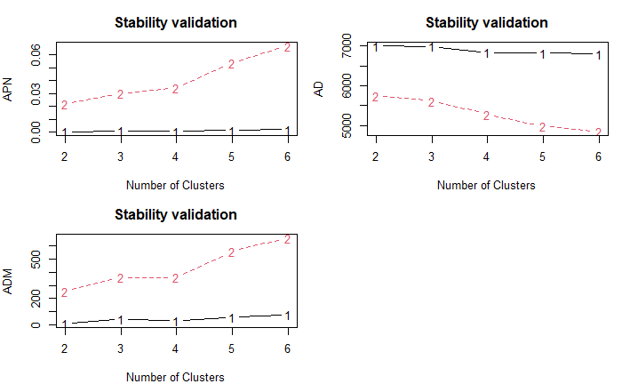

```r
legend("center", clusterMethods(valid.stab), col=1:9, lty=1:9, pch=paste(1:9))
par(op)
```

Here we see that hierarchical-2 and kmeans-6 performs the best in terms of stability. But inb internal validation hierarchical 2 was superior in all 3 metrics. Thus we can conclude that hierarchical-2 is the best.

```r
valid.stabRankWeighs <-getRanksWeights(valid.stab)
print(valid.stabRankWeighs$ranks[,1:3], quote=FALSE)
```

```
    1              2              3
APN hierarchical-2 hierarchical-4 hierarchical-3
AD  kmeans-6       kmeans-5       kmeans-4
ADM hierarchical-2 hierarchical-4 hierarchical-3
FOM kmeans-6       kmeans-5       kmeans-4
```

# Conclusion

In each section comments that are related to that section are made. So in the conclusion general comments are presented. The dataset is hard to work with since the data is not best suitable for clustering. Clusters almost overlap and first two components of PCA only cover the %47(27+20) of the data. For example, if first two components would add up to %80 percent of the data we could see much distinct and non overlapping clusters. Since my dataset also does not have labels, there is no way to verify if the clustering is correct. Thus, this dataset is rather open to comment.